# Guide to analyse Property dataset

This guide would be covering all the steps from basics!!  
Dataset link: https://github.com/ShivangiSharma77/StatusNeo_Task1/tree/main/data

## Hardware and software requirements

**Hardware requirements:**

- Laptop/Desktop/iMac

**Software requirements:**

- Windows operationg system
- Search Engine
- Google account

Internet connection a must.

## 1. Setting up the environment

### 1.1 Switch on your PC by clicking the power button

### 1.2 Connect PC to the internet

You can use Wifi to connect your PC to the internet, toggle to the bottom right of the screen and connect to WiFi by clicking on the WiFi icon then selecting your router.

### 1.3 Open any search engine

Double click on the search engine icon ( ex. google chrome)

### 1.4 Type the following link in the search bar https://colab.research.google.com/notebooks/intro.ipynb#recent=true the link redirects to google collab

Type the above link in the search bar given at the top of the screen. Multiple enviornments can be used for data analysis. We would be conducting the analysis on google collab.

### 1.5 Sign in to google collab

Sign in with your gmail account by selecting the blue sign in button at upper right corner.

### 1.6 Open a new notebook

Select **new notebook** option from **File** option at the upper left corner.

## 2. Getting started

### 2.1 Importing the libraries

Type the following command into the first cell, for importing the necessary libraries which would be used for data analysis.

```python
import numpy as np
import pandas as pd
import matplotlib.pyplot as plt
import matplotlib.image as mpimg
%matplotlib inline
import seaborn as sns
```

## 3. Data loading

We need to load the dataset for analysis.

### 3.1 Importing data files to google collab

Now, the necessary files can be uploaded ie. **Bangalore.csv Chennai.csv Delhi.csv Hyderabad.csv Kolkata.csv Mumbai.csv** from the data folder.

### 3.2 Reading the data files

All the data files are in csv format. To read the data files we write the following function, which will read the files and store them in a dataframe

```python
def read_data(files):
    return pd.read_csv(files)
```

Now read the **delhi.csv** file in df1-

```python
df1 = read_data("Delhi.csv")
```

To view the first 5 rows we use the following command (5 can be replaced with any number of rows we wish to see)

```python
df1.head(5)
```

|  | Price | Area | Location | No. of Bedrooms | Resale | MaintenanceStaff | Gymnasium | SwimmingPool | LandscapedGardens | JoggingTrack | ... | LiftAvailable | BED | VaastuCompliant | Microwave | GolfCourse | TV | DiningTable | Sofa | Wardrobe | Refrigerator |
| --- | --- | --- | --- | --- | --- | --- | --- | --- | --- | --- | --- | --- | --- | --- | --- | --- | --- | --- | --- | --- | --- |
| 0 | 10500000 | 1200 | Sector 10 Dwarka | 2 | 1 | 0 | 1 | 0 | 0 | 1 | ... | 1 | 0 | 1 | 0 | 0 | 0 | 0 | 0 | 0 | 0 |
| 1 | 6000000 | 1000 | Uttam Nagar | 3 | 0 | 0 | 0 | 0 | 0 | 0 | ... | 0 | 0 | 0 | 0 | 0 | 0 | 0 | 0 | 0 | 0 |
| 2 | 15000000 | 1350 | Sarita Vihar | 2 | 1 | 0 | 0 | 0 | 0 | 0 | ... | 0 | 0 | 0 | 0 | 0 | 0 | 0 | 0 | 0 | 0 |
| 3 | 2500000 | 435 | Uttam Nagar | 2 | 0 | 0 | 0 | 0 | 0 | 0 | ... | 0 | 0 | 1 | 0 | 0 | 0 | 0 | 0 | 0 | 0 |
| 4 | 5800000 | 900 | Dwarka Mor | 3 | 0 | 0 | 0 | 0 | 0 | 0 | ... | 1 | 0 | 0 | 0 | 0 | 0 | 0 | 0 | 0 | 0 |

5 rows × 40 columns

Similarly read the all the files **Bangalore.csv Chennai.csv Hyderabad.csv Kolkata.csv Mumbai.csv** in df2,df3,df4,df5,df6 respectively

```python
df2 = read_data("Bangalore.csv")
```

```python
df3 = read_data("Chennai.csv")
```

```python
df4 = read_data("Hyderabad.csv")
```

```python
df5 = read_data("Kolkata.csv")
```

```python
df6 = read_data("Mumbai.csv")
```

### 3.3 Check the shape of the dataframes

The shape property will return a tuple representing the dimensionality of the DataFrame ie. rows and columns. This can be checked by the following commands. Here notice that all the columns are of dimention 40.

```python
df1.shape
```

```
(4998, 40)
```

```python
df2.shape
```

```
(6207, 40)
```

```python
df3.shape
```

```
(5014, 40)
```

```python
df4.shape
```

```
(2518, 40)
```

```python
df5.shape
```

```
(6507, 40)
```

```python
df6.shape
```

```
(7719, 40)
```

## 4. Data Preprocessing

### 4.1 Adding states column to datasets

we can create a new column "States" in all the datasets by adding the repective state. The following function returns the list of state coumn.

```python
def def_state(n,s):
    state=[]
    state += n * [s]
    return state
```

For delhi's dataset we would make the entire state column as delhi, similarly all states can be added in their dataframes.

```python
res1 = def_state(df1.shape[0],"Delhi")
```

```python
res2 = def_state(df2.shape[0],"Bangalore")
```

```python
res3 = def_state(df3.shape[0],"Chennai")
```

```python
res4 = def_state(df4.shape[0],"Hyderabad")
```

```python
res5 = def_state(df5.shape[0],"Kolkata")
```

```python
res6 = def_state(df6.shape[0],"Mumbai")
```

Now we can make a new column "State" in the data frames.

```python
df1['State'] = res1
```

```python
df2['State'] = res2
```

```python
df3['State'] = res3
```

```python
df4['State'] = res4
```

```python
df5['State'] = res5
```

```python
df6['State'] = res6
```

Now notice the new shape of dataframe

```python
df1.shape
```

```
(4998, 41)
```

```python
df2.head(2)
```

|  | Price | Area | Location | No. of Bedrooms | Resale | MaintenanceStaff | Gymnasium | SwimmingPool | LandscapedGardens | JoggingTrack | ... | BED | VaastuCompliant | Microwave | GolfCourse | TV | DiningTable | Sofa | Wardrobe | Refrigerator | State |
| --- | --- | --- | --- | --- | --- | --- | --- | --- | --- | --- | --- | --- | --- | --- | --- | --- | --- | --- | --- | --- | --- |
| 0 | 30000000 | 3340 | JP Nagar Phase 1 | 4 | 0 | 1 | 1 | 1 | 1 | 1 | ... | 0 | 0 | 0 | 0 | 0 | 0 | 0 | 0 | 0 | Bangalore |
| 1 | 7888000 | 1045 | Dasarahalli on Tumkur Road | 2 | 0 | 0 | 1 | 1 | 1 | 1 | ... | 0 | 1 | 0 | 0 | 0 | 0 | 0 | 0 | 0 | Bangalore |

2 rows × 41 columns

### 4.2 Merging the dataframes

Create a new list with all the dataframes as follows-

```python
frames = [df1,df2,df3,df4,df5,df6]
```

Concat the frames together

```python
data = pd.concat(frames)
```

Save the new dataset as "Merged_csv.csv"

```python
data.to_csv(r'.\Merged_csv.csv', index = False)
```

Check the shape of new dataframe

```python
data.shape
```

```
(32963, 41)
```

```python
data.tail(5)
```

|  | Price | Area | Location | No. of Bedrooms | Resale | MaintenanceStaff | Gymnasium | SwimmingPool | LandscapedGardens | JoggingTrack | ... | BED | VaastuCompliant | Microwave | GolfCourse | TV | DiningTable | Sofa | Wardrobe | Refrigerator | State |
| --- | --- | --- | --- | --- | --- | --- | --- | --- | --- | --- | --- | --- | --- | --- | --- | --- | --- | --- | --- | --- | --- |
| 7714 | 14500000 | 1180 | Mira Road East | 2 | 0 | 9 | 9 | 9 | 9 | 9 | ... | 9 | 9 | 9 | 9 | 9 | 9 | 9 | 9 | 9 | Mumbai |
| 7715 | 14500000 | 530 | Naigaon East | 1 | 1 | 9 | 9 | 9 | 9 | 9 | ... | 9 | 9 | 9 | 9 | 9 | 9 | 9 | 9 | 9 | Mumbai |
| 7716 | 4100000 | 700 | Shirgaon | 1 | 0 | 9 | 9 | 9 | 9 | 9 | ... | 9 | 9 | 9 | 9 | 9 | 9 | 9 | 9 | 9 | Mumbai |
| 7717 | 2750000 | 995 | Mira Road East | 2 | 0 | 9 | 9 | 9 | 9 | 9 | ... | 9 | 9 | 9 | 9 | 9 | 9 | 9 | 9 | 9 | Mumbai |
| 7718 | 2750000 | 1020 | Mira Road East | 2 | 0 | 9 | 9 | 9 | 9 | 9 | ... | 9 | 9 | 9 | 9 | 9 | 9 | 9 | 9 | 9 | Mumbai |

5 rows × 41 columns

### 4.3 Explore the dataset

To see the information of the entire dataset follow the command -

```python
print(data.info())
```

```
<class 'pandas.core.frame.DataFrame'>
Int64Index: 32963 entries, 0 to 7718
Data columns (total 41 columns):
 #   Column               Non-Null Count  Dtype
---  ------               --------------  -----
 0   Price                32963 non-null  int64
 1   Area                 32963 non-null  int64
 2   Location             32963 non-null  object
 3   No. of Bedrooms      32963 non-null  int64
 4   Resale               32963 non-null  int64
 5   MaintenanceStaff     32963 non-null  int64
 6   Gymnasium            32963 non-null  int64
 7   SwimmingPool         32963 non-null  int64
 8   LandscapedGardens    32963 non-null  int64
 9   JoggingTrack         32963 non-null  int64
```

[output cut: 34 more lines]

### 4.4 Checking for null values

We would check the number of null values by the following command

```python
data.isnull().sum()
```

```
Price                  0
Area                   0
Location               0
No. of Bedrooms        0
Resale                 0
MaintenanceStaff       0
Gymnasium              0
SwimmingPool           0
LandscapedGardens      0
JoggingTrack           0
RainWaterHarvesting    0
IndoorGames            0
ShoppingMall           0
Intercom               0
SportsFacility         0
ATM                    0
ClubHouse              0
School                 0
24X7Security           0
PowerBackup            0
CarParking             0
StaffQuarter           0
Cafeteria              0
MultipurposeRoom       0
Hospital               0
WashingMachine         0
Gasconnection          0
AC                     0
Wifi                   0
Children'splayarea     0
LiftAvailable          0
BED                    0
VaastuCompliant        0
Microwave              0
GolfCourse             0
TV                     0
DiningTable            0
Sofa                   0
Wardrobe               0
Refrigerator           0
State                  0
dtype: int64
```

### 4.5 Drop Duplicates

We would drop all the duplicate values for better analytical results

```python
data= data.drop_duplicates()
data
```

|  | Price | Area | Location | No. of Bedrooms | Resale | MaintenanceStaff | Gymnasium | SwimmingPool | LandscapedGardens | JoggingTrack | ... | BED | VaastuCompliant | Microwave | GolfCourse | TV | DiningTable | Sofa | Wardrobe | Refrigerator | State |
| --- | --- | --- | --- | --- | --- | --- | --- | --- | --- | --- | --- | --- | --- | --- | --- | --- | --- | --- | --- | --- | --- |
| 0 | 10500000 | 1200 | Sector 10 Dwarka | 2 | 1 | 0 | 1 | 0 | 0 | 1 | ... | 0 | 1 | 0 | 0 | 0 | 0 | 0 | 0 | 0 | Delhi |
| 1 | 6000000 | 1000 | Uttam Nagar | 3 | 0 | 0 | 0 | 0 | 0 | 0 | ... | 0 | 0 | 0 | 0 | 0 | 0 | 0 | 0 | 0 | Delhi |
| 2 | 15000000 | 1350 | Sarita Vihar | 2 | 1 | 0 | 0 | 0 | 0 | 0 | ... | 0 | 0 | 0 | 0 | 0 | 0 | 0 | 0 | 0 | Delhi |
| 3 | 2500000 | 435 | Uttam Nagar | 2 | 0 | 0 | 0 | 0 | 0 | 0 | ... | 0 | 1 | 0 | 0 | 0 | 0 | 0 | 0 | 0 | Delhi |
| 4 | 5800000 | 900 | Dwarka Mor | 3 | 0 | 0 | 0 | 0 | 0 | 0 | ... | 0 | 0 | 0 | 0 | 0 | 0 | 0 | 0 | 0 | Delhi |
| ... | ... | ... | ... | ... | ... | ... | ... | ... | ... | ... | ... | ... | ... | ... | ... | ... | ... | ... | ... | ... | ... |
| 7714 | 14500000 | 1180 | Mira Road East | 2 | 0 | 9 | 9 | 9 | 9 | 9 | ... | 9 | 9 | 9 | 9 | 9 | 9 | 9 | 9 | 9 | Mumbai |
| 7715 | 14500000 | 530 | Naigaon East | 1 | 1 | 9 | 9 | 9 | 9 | 9 | ... | 9 | 9 | 9 | 9 | 9 | 9 | 9 | 9 | 9 | Mumbai |
| 7716 | 4100000 | 700 | Shirgaon | 1 | 0 | 9 | 9 | 9 | 9 | 9 | ... | 9 | 9 | 9 | 9 | 9 | 9 | 9 | 9 | 9 | Mumbai |
| 7717 | 2750000 | 995 | Mira Road East | 2 | 0 | 9 | 9 | 9 | 9 | 9 | ... | 9 | 9 | 9 | 9 | 9 | 9 | 9 | 9 | 9 | Mumbai |
| 7718 | 2750000 | 1020 | Mira Road East | 2 | 0 | 9 | 9 | 9 | 9 | 9 | ... | 9 | 9 | 9 | 9 | 9 | 9 | 9 | 9 | 9 | Mumbai |

29135 rows × 41 columns

### 4.6 Renaming column

Column name can be renamed by the following command

```python
data=data.rename(columns={"No. of Bedrooms": "Number_Bedrooms", })
```

### 4.7 View Columns

We can view all the columns by the following command

```python
data.columns
```

```
Index(['Price', 'Area', 'Location', 'Number_Bedrooms', 'Resale',
       'MaintenanceStaff', 'Gymnasium', 'SwimmingPool', 'LandscapedGardens',
       'JoggingTrack', 'RainWaterHarvesting', 'IndoorGames', 'ShoppingMall',
       'Intercom', 'SportsFacility', 'ATM', 'ClubHouse', 'School',
       '24X7Security', 'PowerBackup', 'CarParking', 'StaffQuarter',
       'Cafeteria', 'MultipurposeRoom', 'Hospital', 'WashingMachine',
       'Gasconnection', 'AC', 'Wifi', 'Children'splayarea', 'LiftAvailable',
       'BED', 'VaastuCompliant', 'Microwave', 'GolfCourse', 'TV',
       'DiningTable', 'Sofa', 'Wardrobe', 'Refrigerator', 'State'],
      dtype='object')
```

## 5. Analyzing data

Describe the entire dataframe to analyse different aspects of the data

```python
data.describe()
```

|  | Price | Area | Number_Bedrooms | Resale | MaintenanceStaff | Gymnasium | SwimmingPool | LandscapedGardens | JoggingTrack | RainWaterHarvesting | ... | LiftAvailable | BED | VaastuCompliant | Microwave | GolfCourse | TV | DiningTable | Sofa | Wardrobe | Refrigerator |
| --- | --- | --- | --- | --- | --- | --- | --- | --- | --- | --- | --- | --- | --- | --- | --- | --- | --- | --- | --- | --- | --- |
| count | 2.913500e+04 | 29135.000000 | 29135.000000 | 29135.000000 | 29135.000000 | 29135.000000 | 29135.000000 | 29135.000000 | 29135.000000 | 29135.000000 | ... | 29135.000000 | 29135.000000 | 29135.000000 | 29135.000000 | 29135.000000 | 29135.000000 | 29135.000000 | 29135.000000 | 29135.000000 | 29135.000000 |
| mean | 1.195267e+07 | 1301.816475 | 2.421074 | 0.377038 | 6.507088 | 6.608581 | 6.578479 | 6.560975 | 6.555929 | 6.563858 | ... | 6.662331 | 6.485979 | 6.542990 | 6.474584 | 6.465282 | 6.475922 | 6.475648 | 6.475545 | 6.465351 | 6.475270 |
| std | 2.387647e+07 | 767.862339 | 0.821016 | 0.484653 | 3.979560 | 3.821937 | 3.869633 | 3.896995 | 3.904831 | 3.892507 | ... | 3.734651 | 4.011243 | 3.924827 | 4.028196 | 4.041958 | 4.026210 | 4.026618 | 4.026770 | 4.041857 | 4.027178 |
| min | 2.000000e+06 | 200.000000 | 1.000000 | 0.000000 | 0.000000 | 0.000000 | 0.000000 | 0.000000 | 0.000000 | 0.000000 | ... | 0.000000 | 0.000000 | 0.000000 | 0.000000 | 0.000000 | 0.000000 | 0.000000 | 0.000000 | 0.000000 | 0.000000 |
| 25% | 4.179999e+06 | 870.000000 | 2.000000 | 0.000000 | 1.000000 | 1.000000 | 1.000000 | 1.000000 | 1.000000 | 1.000000 | ... | 1.000000 | 0.000000 | 1.000000 | 0.000000 | 0.000000 | 0.000000 | 0.000000 | 0.000000 | 0.000000 | 0.000000 |
| 50% | 6.884999e+06 | 1137.000000 | 2.000000 | 0.000000 | 9.000000 | 9.000000 | 9.000000 | 9.000000 | 9.000000 | 9.000000 | ... | 9.000000 | 9.000000 | 9.000000 | 9.000000 | 9.000000 | 9.000000 | 9.000000 | 9.000000 | 9.000000 | 9.000000 |
| 75% | 1.230000e+07 | 1504.000000 | 3.000000 | 1.000000 | 9.000000 | 9.000000 | 9.000000 | 9.000000 | 9.000000 | 9.000000 | ... | 9.000000 | 9.000000 | 9.000000 | 9.000000 | 9.000000 | 9.000000 | 9.000000 | 9.000000 | 9.000000 | 9.000000 |
| max | 8.546000e+08 | 16000.000000 | 9.000000 | 1.000000 | 9.000000 | 9.000000 | 9.000000 | 9.000000 | 9.000000 | 9.000000 | ... | 9.000000 | 9.000000 | 9.000000 | 9.000000 | 9.000000 | 9.000000 | 9.000000 | 9.000000 | 9.000000 | 9.000000 |

8 rows × 39 columns

### 5.1 Checking the unique values

Check the unique values of price and area and display first 50 values

```python
np.unique(data[['Price','Area']].head(50), axis=0)
```

```
array([[  2350000,       415],
       [  2350000,       550],
       [  2500000,       435],
       [  2500000,       630],
       [  2700000,       540],
       [  2750000,       630],
       [  3000000,       650],
       [  3300000,       385],
       [  3500000,       675],
       [  3600000,       675],
       [  3600000,      1050],
       [  3621000,       900],
       [  3800000,       450],
       [  4699000,       850],
       [  4999000,       950],
       [  5000000,      1000],
       [  5100000,       900],
       [  5499000,       900],
       [  5500000,      1000],
       [  5800000,       900],
       [  6000000,      1000],
       [  6500000,      1000],
       [  8000000,      1500],
       [  8500000,      1200],
       [  9200000,      1200],
       [ 10400000,      1125],
       [ 10500000,      1200],
       [ 11000000,      1000],
       [ 12500000,       600],
       [ 12500000,      1000],
       [ 12500000,      1300],
       [ 12500000,      1550],
       [ 12800000,      1843],
       [ 13500000,      1350],
       [ 13500000,      1800],
       [ 14800000,      1750],
       [ 14800000,      1800],
       [ 15000000,      1350],
       [ 15000000,      1551],
       [ 15400000,      1500],
       [ 15800000,      1800],
       [ 16200000,      1600],
       [ 16500000,      1600],
       [ 17500000,      1300],
       [ 17500000,      1650],
       [ 23500000,      2000],
       [ 27500000,      3000],
       [ 45000000,      4600],
       [110000000,      2500]], dtype=int64)
```

Check the unique values of MaintenanceStaff

```python
len(data.MaintenanceStaff.unique())
```

```
3
```

Check the unique values of Number of bedrooms

```python
data.Number_Bedrooms.unique()
```

```
array([2, 3, 4, 1, 5, 6, 8, 7, 9], dtype=int64)
```

Check the unique values of Location

```python
len(data.Location.unique())
```

```
1776
```

Check the unique values of States

```python
len(data.State.unique())
```

```
6
```

### 5.2 Setting the figure

We can set the seaborn figure size and style to 10,8 and white respectively

```python
sns.set(rc={'figure.figsize':(10,8)})
sns.set_style('white')
```

## 6. Deriving insights

### 6.1 Maximum price

we can find the maximum price of property

```python
max_price=data['Price'].max()
print(max_price)
```

```
854599999
```

### 6.2 Minimum price

we can find the minimum price of property

```python
min_price=data['Price'].min()
print(min_price)
```

```
2000000
```

### 6.3 average price

we can find the average price of property

```python
avg=data["Price"].mean()
print(avg)
```

```
11952667.000034323
```

### 6.4 Location of maximum price

we can find the location of maximum price of property

```python
data.iloc[data['Price'].idxmax()]['Location']
```

```
'Noida'
```

### 6.5 location of minimum price

we can find the location of minimum price of property

```python
data.iloc[data['Price'].idxmin()]['Location']
```

```
'Burari'
```

### 6.5 Area of maximum price

we can find the area of maximum price of property

```python
data.iloc[data['Price'].idxmax()]['Area']
```

[output not shown]

### 6.6 Area size of minimum price

we can find the area of minimum price of property

```python
data.iloc[data['Price'].idxmin()]['Area']
```

```
750
```

### 6.7 Relationship between price and area

We can define the relationship bw price and area with the help of jointplot, using area and price as the x and y axis respectively

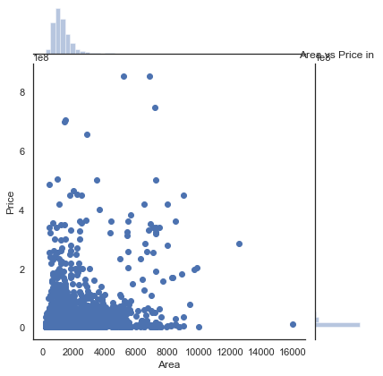

```python
sns.jointplot(x="Area", y="Price", data=data)
plt.title('Area vs Price in ')
plt.show()
```

### 6.8 number of bedrooms of maximum price

We can check the number of bedrooms of the property with the maximum priced property by firstly identifying the property of max price by using "idmax" then select its number of bedrooms

```python
data.iloc[data['Price'].idxmax()]['Number_Bedrooms']
```

```
3
```

### 6.9 number of bedrooms of minimum price

We can check the number of bedrooms of the property with the minimum priced property by firstly identifying the property of min price by using "idmin" then select its number of bedrooms

```python
data.iloc[data['Price'].idxmin()]['Number_Bedrooms']
```

```
2
```

### 6.10 Number of bedrooms according to price

We can define the relationship bw price and number of bedrooms with the help of barplot, using Number_Bedrooms and price as the x and y axis respectively.

```
[Text(0, 0, '1'),
```

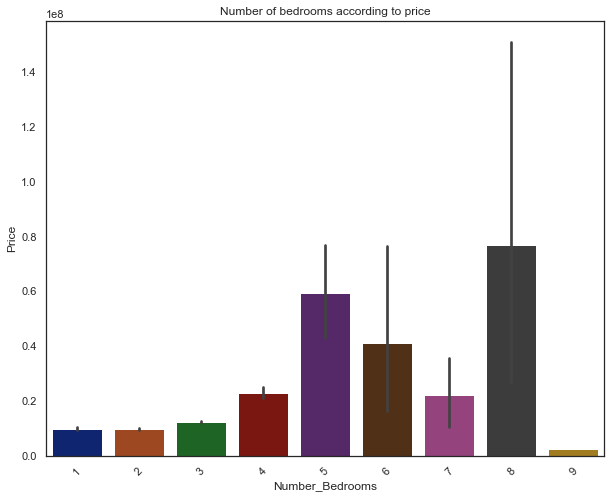

```python
viz_1=sns.barplot(x="Number_Bedrooms", y="Price", data=data,
                 palette='dark')
viz_1.set_title('Number of bedrooms according to price')
viz_1.set_ylabel('Price')
viz_1.set_xlabel('Number_Bedrooms')
viz_1.set_xticklabels(viz_1.get_xticklabels(), rotation=45)
```

### 6.11 Check if the property with maximum price resale

We can check if the property with max price was resaled (1 for resale, 0 for no sale)

```python
data.iloc[data['Price'].idxmax()]['Resale']
```

```
1
```

### 6.11 Check if the property with minimum price resale

We can check if the property with min price was resaled (1 for resale, 0 for no sale)

```python
data.iloc[data['Price'].idxmin()]['Resale']
```

```
1
```

### 6.12 Total number of resales

We can check the total number of properties that were resaled

```python
(data.Resale==1).sum()
```

```
10985
```

### 6.13 state having highest price

We can check the state with the maximum priced property by firstly identifying the property of max price by using "idmax" then select its state

```python
data.iloc[data['Price'].idxmax()]['State']
```

```
'Delhi'
```

We can check the state with the minimum priced property by firstly identifying the property of min price by using "idmin" then select its state

```python
data.iloc[data['Price'].idxmin()]['State']
```

```
'Delhi'
```

### 6.15 Relationship between State and Price

We can define the relationship bw state and price with the help of barplot, using State and price as the x and y axis respectively.

```
[Text(0, 0, 'Delhi'),
```

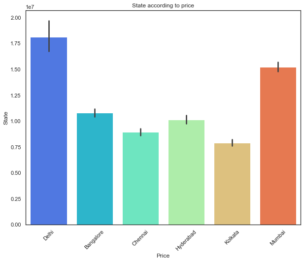

```python
viz_1=sns.barplot(x="State", y="Price", data=data,
                 palette='rainbow')
viz_1.set_title('State according to price')
viz_1.set_ylabel('State')
viz_1.set_xlabel('Price')
viz_1.set_xticklabels(viz_1.get_xticklabels(), rotation=45)
```

### 6.16 State has largest area

We can check the state having largest area size firstly identifying the property of max area by using "idmax" then select its state

```python
data.iloc[data['Area'].idxmax()]['State']
```

```
'Delhi'
```

### 6.17 State has smallest area

```python
data.iloc[data['Area'].idxmin()]['State']
```

```
'Delhi'
```

### 6.18 Relationship between States and Areas

We can define the relationship bw state and area with the help of barplot, using State and area as the y and x axis respectively.

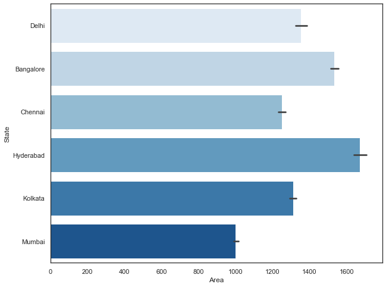

```python
sns.barplot(y = data.State, x = data.Area, orient='h', palette="Blues")
plt.show()
```

### 6.19 Number of resales and no sales in each state

We can define the number of resales and no sales by grouping each state and counting the resale values

```python
data.groupby('State')['Resale'].value_counts()
```

```
State      Resale
Bangalore  0         5114
           1          407
Chennai    0         3880
           1          427
Delhi      1         3234
           0          875
Hyderabad  0         1472
           1          526
Kolkata    0         4292
           1         1983
Mumbai     1         4408
           0         2517
Name: Resale, dtype: int64
```

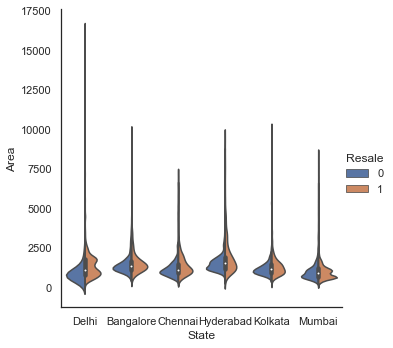

```python
sns.catplot(x="State", y="Area", hue="Resale",split=True, kind="violin",data=data)
```

### 6.19 Locations

Determine the count in each location limiting it to 15 by using a countplot for locations

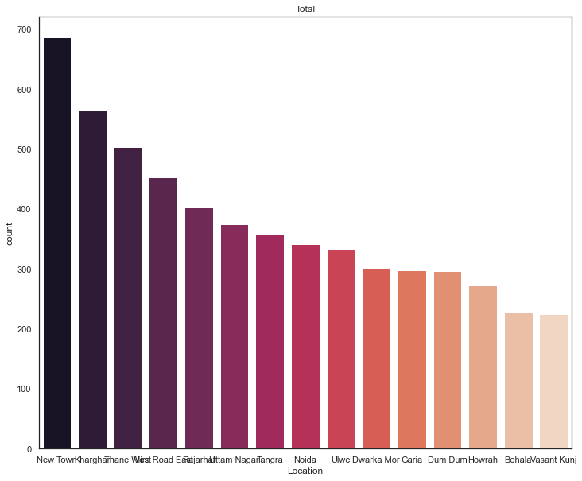

```python
plt.figure(figsize=(12,10))
plt.title('Total')
sns.countplot(x='Location',data=data,order= data.Location.value_counts().index[:15],palette = "rocket")
```

### 6.20 Count of columns

We can create countplot by any attribute by using the below function

```python
def plots(plot):
    fig,ax=plt.subplots(figsize=(12,8))
    return sns.countplot(data[plot], ax=ax)
```

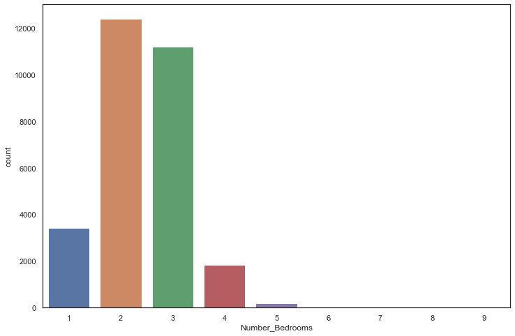

```python
plots("Number_Bedrooms")
```

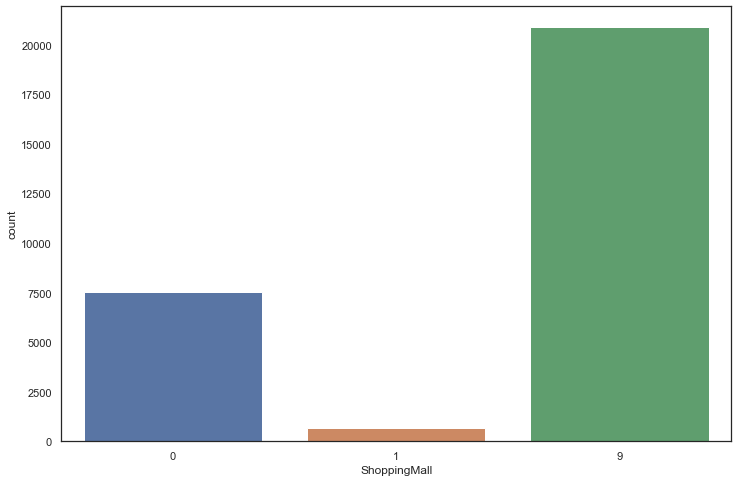

```python
plots("ShoppingMall")
```

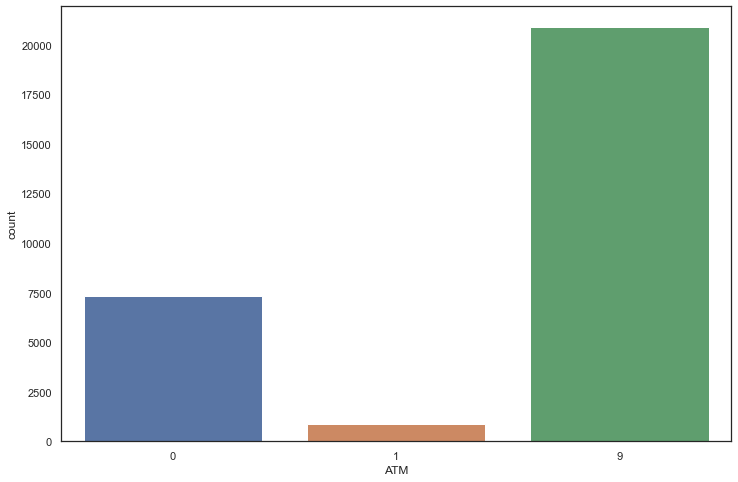

```python
plots("ATM")
```

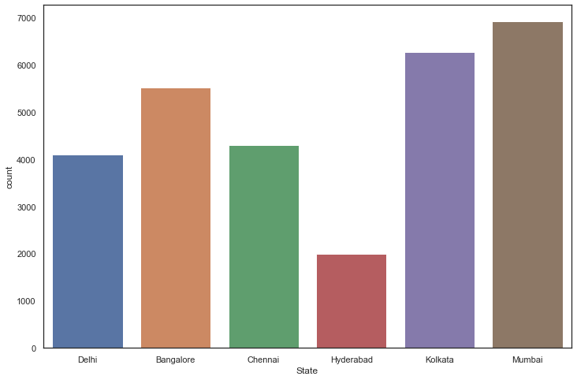

```python
plots("State")
```

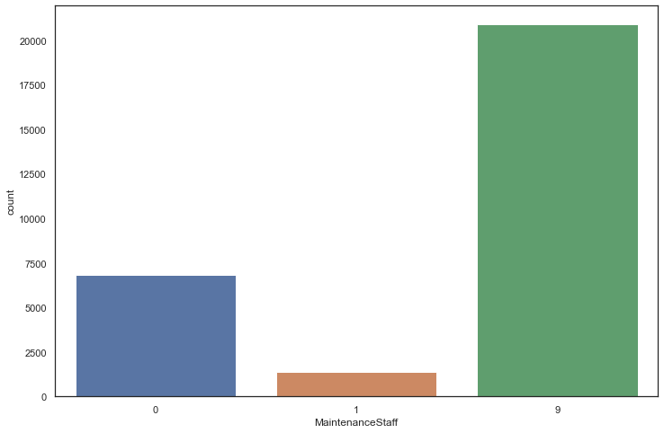

```python
plots("MaintenanceStaff")
```

### 6.21 Estimate by area

We can create histogram with KDE by setting "KDE=True" with area by below commands

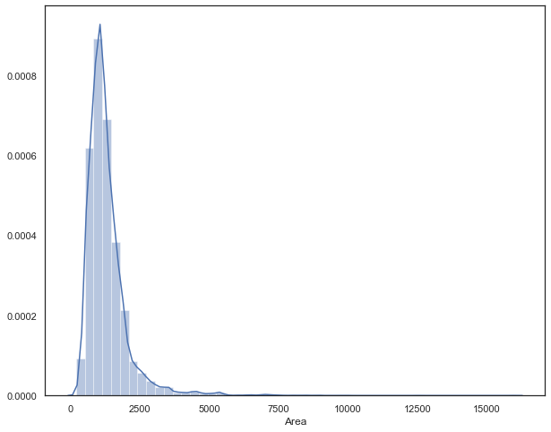

```python
sns.distplot(data['Area'], hist=True, kde=True)
```

### 6.22 Availability of clubhouses according to price

We would create a catplot to define the relationship between clubhouse and price.

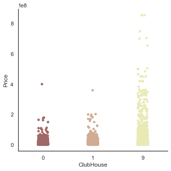

```python
viz_1=sns.catplot(x="ClubHouse", y="Price", data=data,
                 palette='pink')
```

### 6.23 Gymnasium availability according to Price

We can determine the relation between gymnasium according to price of the property, we can use the bar plot to showcase the relation

```
[Text(0, 0, '0'), Text(0, 0, '1'), Text(0, 0, '9')]
```

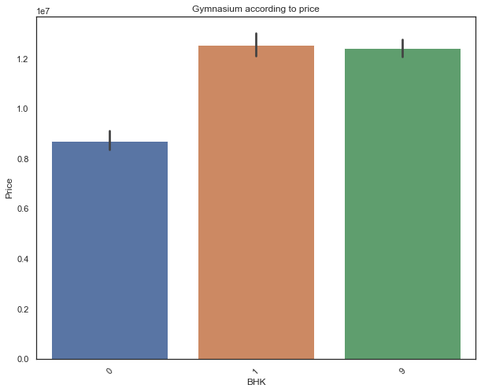

```python
viz_1=sns.barplot(x="Gymnasium", y="Price", data=data,
                 )
viz_1.set_title('Gymnasium according to price')
viz_1.set_ylabel('Price')
viz_1.set_xlabel('BHK')
viz_1.set_xticklabels(viz_1.get_xticklabels(), rotation=45)
```

### 6.24 Estimation of percentage of resales

[figure not shown]

```python
resale = data.Resale.count()
nosale = (data.Resale==0).sum()
labels = ["Resale", "No Resale"]
total = float(resale + nosale)
sizes = [(resale/total)*100, (nosale/total)*100]
colors = ['purple', 'pink']
plt.pie(sizes, labels=labels, colors=colors,
        autopct='%1.1f%%', shadow=True, startangle=90)
plt.title("Percentage of resale")
plt.show()
```

### 6.25 Density distribution of Schools

Create a violinplot distributon of schools and area

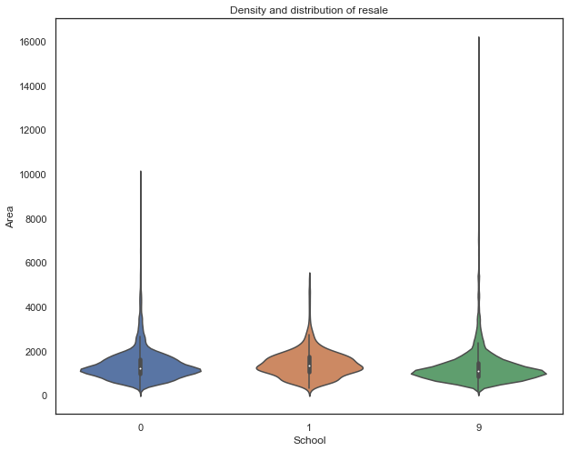

```python
viz_2=sns.violinplot(data=data, x='School', y='Area')
viz_2.set_title('Density and distribution of resale')
```

### 6.26 Density distribution of Hospitals

Create a density distribution of hospitals with violinplot of hospitals with area

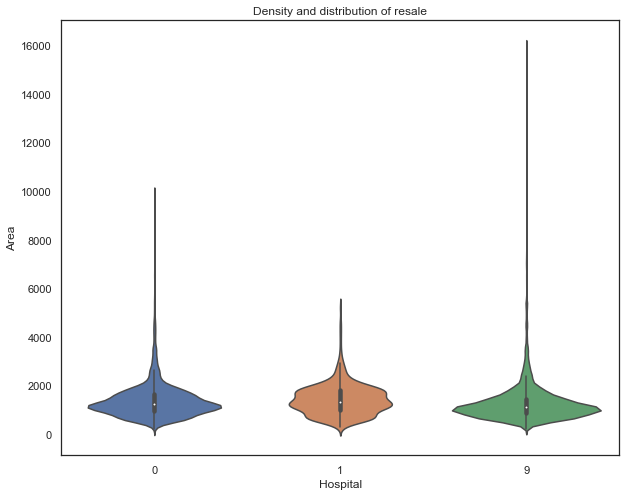

```python
viz_3=sns.violinplot(data=data, x='Hospital', y='Area')
viz_3.set_title('Density and distribution of resale')
```

### 6.27 Resale count according to number of bedrooms

Estimate the count of number of bedrooms and resales by using countplot

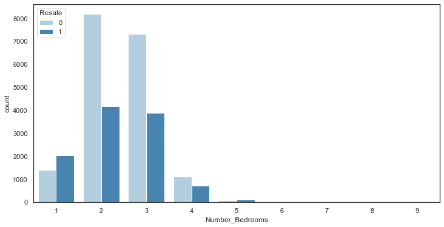

```python
plt.figure(figsize=(12,6))
sns.countplot(x='Number_Bedrooms', hue='Resale', data=data, palette="Blues")
plt.xticks(rotation='horizontal')
plt.show()
```

### 6.28 Security conditions affecting resale value

We define the relation bw security and resales by using barplot, with pastel palette that defines the colour stack used

```
[Text(0, 0, '0'), Text(0, 0, '1'), Text(0, 0, '9')]
```

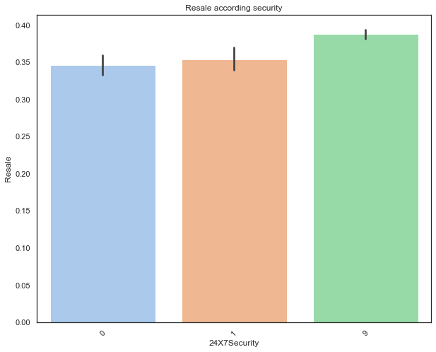

```python
viz_1=sns.barplot(x="24X7Security", y="Resale", data=data,
                 palette='pastel')
viz_1.set_title('Resale according security')
viz_1.set_ylabel('Resale')
viz_1.set_xlabel('24X7Security')
viz_1.set_xticklabels(viz_1.get_xticklabels(), rotation=45)
```

### 6.29 largest area

We can find the largest area of all properties by using the max function

```python
data['Area'].max()
```

```
16000
```

### 6.30 smaller area

We can find the smallest area of all properties by using the min function

```python
data['Area'].min()
```

```
200
```

### 6.31 average area

We can find the average area of all properties by using the mean function

```python
data['Area'].mean()
```

```
1301.8164750300325
```

### 6.32 location of largest area

Find the location of property of largest area by first find the max area then providing its location

```python
data.iloc[data['Area'].idxmax()]['Location']
```

```
'Vikas Puri'
```

### 6.33 location of smallest area

```python
data.iloc[data['Area'].idxmin()]['Location']
```

```
'Vasant Kunj'
```

```python
data.iloc[data['Price'].idxmax()]['Area']
```

[output not shown]

### 6.35 Number of Bedrooms according to area

Determine the relation bw number of bedrooms and area by a barplot

```
[Text(0, 0, '1'),
```

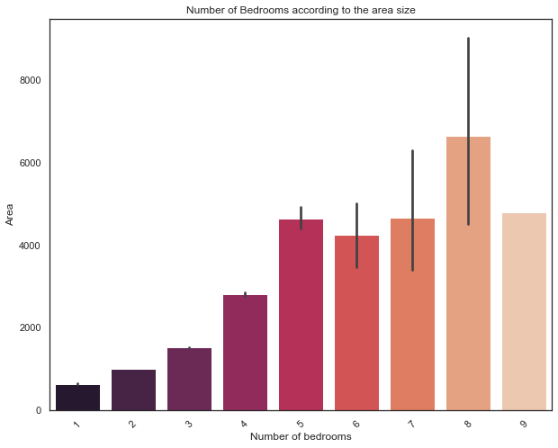

```python
viz_1=sns.barplot(x="Number_Bedrooms", y="Area", data=data,
                 palette='rocket')
viz_1.set_title('Number of Bedrooms according to the area size')
viz_1.set_ylabel('Area')
viz_1.set_xlabel('Number of bedrooms')
viz_1.set_xticklabels(viz_1.get_xticklabels(), rotation=45)
```

### 6.36 Percentage of Golfcourses

[figure not shown]

```python
park = data.GolfCourse.count()
nopark = (data.GolfCourse==0).sum()
labels = ["GolfCourse", "No GolfCourse"]
total = float(park + nopark)
sizes = [(park/total)*100, (nopark/total)*100]
colors = ['yellow', 'red']
plt.pie(sizes, labels=labels, colors=colors,
        autopct='%1.1f%%', shadow=True, startangle=90)
plt.title("Percentage of GolfCourses available")
plt.show()
```

### 6.37 Count of resales affected by vaastu complain

Vaastu complain affecting resales can be represented by the below countplot with resale as hue to show resales and no resales

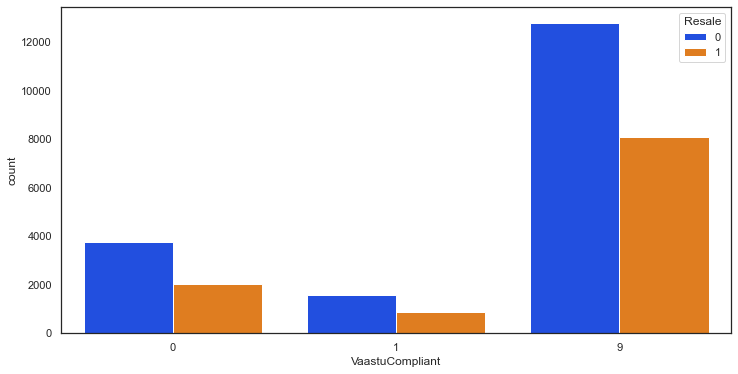

```python
plt.figure(figsize=(12,6))
sns.countplot(x='VaastuCompliant', hue='Resale', data=data, palette="bright")
plt.xticks(rotation='horizontal')
plt.show()
```

## 7. Determining corelation between features

We can figure out the corelation between features ie. understand the relationship between multiple variables and attributes in the dataset. Using Correlation, we can get some insights such as: One or multiple attributes depend on another attribute or a cause for another attribute.

```python
data.corr()
```

|  | Price | Area | Number_Bedrooms | Resale | MaintenanceStaff | Gymnasium | SwimmingPool | LandscapedGardens | JoggingTrack | RainWaterHarvesting | ... | LiftAvailable | BED | VaastuCompliant | Microwave | GolfCourse | TV | DiningTable | Sofa | Wardrobe | Refrigerator |
| --- | --- | --- | --- | --- | --- | --- | --- | --- | --- | --- | --- | --- | --- | --- | --- | --- | --- | --- | --- | --- | --- |
| Price | 1.000000 | 0.268954 | 0.150691 | 0.069200 | 0.032885 | 0.034510 | 0.034732 | 0.033949 | 0.033608 | 0.034344 | ... | 0.032917 | 0.032959 | 0.032852 | 0.032463 | 0.032057 | 0.032533 | 0.032462 | 0.032537 | 0.032346 | 0.032618 |
| Area | 0.268954 | 1.000000 | 0.709645 | -0.034765 | -0.059873 | -0.049886 | -0.048989 | -0.051923 | -0.051318 | -0.052870 | ... | -0.055637 | -0.058412 | -0.054999 | -0.057585 | -0.058877 | -0.057990 | -0.057825 | -0.057800 | -0.058996 | -0.057844 |
| Number_Bedrooms | 0.150691 | 0.709645 | 1.000000 | -0.071209 | -0.049175 | -0.042257 | -0.041128 | -0.043009 | -0.042774 | -0.044588 | ... | -0.043820 | -0.046818 | -0.044881 | -0.045512 | -0.046649 | -0.045715 | -0.045645 | -0.045796 | -0.046659 | -0.045673 |
| Resale | 0.069200 | -0.034765 | -0.071209 | 1.000000 | 0.042011 | 0.029088 | 0.026783 | 0.030235 | 0.028876 | 0.034170 | ... | 0.035259 | 0.038587 | 0.035444 | 0.034859 | 0.034761 | 0.035321 | 0.035036 | 0.035618 | 0.037009 | 0.035087 |
| MaintenanceStaff | 0.032885 | -0.059873 | -0.049175 | 0.042011 | 1.000000 | 0.996797 | 0.996695 | 0.997246 | 0.997189 | 0.997621 | ... | 0.997144 | 0.998359 | 0.997588 | 0.998262 | 0.998694 | 0.998258 | 0.998221 | 0.998238 | 0.998638 | 0.998242 |
| Gymnasium | 0.034510 | -0.049886 | -0.042257 | 0.029088 | 0.996797 | 1.000000 | 0.998874 | 0.998054 | 0.998347 | 0.997654 | ... | 0.997203 | 0.997166 | 0.997305 | 0.997372 | 0.997591 | 0.997289 | 0.997391 | 0.997417 | 0.997378 | 0.997363 |
| SwimmingPool | 0.034732 | -0.048989 | -0.041128 | 0.026783 | 0.996695 | 0.998874 | 1.000000 | 0.998323 | 0.998605 | 0.997882 | ... | 0.997056 | 0.997024 | 0.997590 | 0.997551 | 0.997729 | 0.997436 | 0.997564 | 0.997565 | 0.997508 | 0.997538 |
| LandscapedGardens | 0.033949 | -0.051923 | -0.043009 | 0.030235 | 0.997246 | 0.998054 | 0.998323 | 1.000000 | 0.998572 | 0.998177 | ... | 0.997000 | 0.997158 | 0.997736 | 0.997562 | 0.997887 | 0.997468 | 0.997565 | 0.997596 | 0.997714 | 0.997564 |
| JoggingTrack | 0.033608 | -0.051318 | -0.042774 | 0.028876 | 0.997189 | 0.998347 | 0.998605 | 0.998572 | 1.000000 | 0.998344 | ... | 0.996911 | 0.997090 | 0.998150 | 0.997604 | 0.997963 | 0.997521 | 0.997578 | 0.997576 | 0.997692 | 0.997594 |
| RainWaterHarvesting | 0.034344 | -0.052870 | -0.044588 | 0.034170 | 0.997621 | 0.997654 | 0.997882 | 0.998177 | 0.998344 | 1.000000 | ... | 0.996991 | 0.997026 | 0.998215 | 0.997447 | 0.997820 | 0.997435 | 0.997432 | 0.997444 | 0.997690 | 0.997453 |
| IndoorGames | 0.033470 | -0.052117 | -0.042275 | 0.027876 | 0.997224 | 0.998110 | 0.998390 | 0.998520 | 0.998505 | 0.998212 | ... | 0.997013 | 0.997346 | 0.997707 | 0.997845 | 0.998195 | 0.997757 | 0.997804 | 0.997804 | 0.997939 | 0.997823 |
| ShoppingMall | 0.032102 | -0.058614 | -0.046704 | 0.035260 | 0.998566 | 0.997526 | 0.997722 | 0.997822 | 0.998053 | 0.997828 | ... | 0.997602 | 0.998542 | 0.998205 | 0.998893 | 0.999376 | 0.998843 | 0.998869 | 0.998874 | 0.999183 | 0.998881 |
| Intercom | 0.033598 | -0.052035 | -0.040312 | 0.032186 | 0.996807 | 0.997450 | 0.997495 | 0.997235 | 0.997326 | 0.997003 | ... | 0.997183 | 0.996932 | 0.996983 | 0.997603 | 0.997579 | 0.997398 | 0.997462 | 0.997466 | 0.997379 | 0.997468 |
| SportsFacility | 0.034145 | -0.051646 | -0.041530 | 0.034152 | 0.997119 | 0.997768 | 0.997768 | 0.997294 | 0.997396 | 0.997145 | ... | 0.997158 | 0.997661 | 0.996966 | 0.998167 | 0.998200 | 0.998088 | 0.998119 | 0.998126 | 0.997907 | 0.998123 |
| ATM | 0.032073 | -0.058251 | -0.046746 | 0.034516 | 0.998341 | 0.997520 | 0.997745 | 0.997836 | 0.998029 | 0.997892 | ... | 0.997586 | 0.998356 | 0.998095 | 0.998727 | 0.999109 | 0.998669 | 0.998699 | 0.998705 | 0.998994 | 0.998710 |
| ClubHouse | 0.034854 | -0.049145 | -0.040976 | 0.030894 | 0.996965 | 0.998636 | 0.998748 | 0.997916 | 0.998267 | 0.997824 | ... | 0.997171 | 0.997190 | 0.997630 | 0.997662 | 0.997737 | 0.997461 | 0.997542 | 0.997541 | 0.997450 | 0.997545 |
| School | 0.031949 | -0.059146 | -0.047084 | 0.035945 | 0.998488 | 0.997458 | 0.997582 | 0.997734 | 0.997984 | 0.997818 | ... | 0.997639 | 0.998628 | 0.998147 | 0.998954 | 0.999371 | 0.998901 | 0.998929 | 0.998934 | 0.999251 | 0.998941 |
| 24X7Security | 0.034496 | -0.053177 | -0.046404 | 0.035545 | 0.997866 | 0.997778 | 0.997754 | 0.998139 | 0.998418 | 0.998382 | ... | 0.996941 | 0.997290 | 0.997857 | 0.997286 | 0.997642 | 0.997241 | 0.997287 | 0.997324 | 0.997608 | 0.997287 |
| PowerBackup | 0.034678 | -0.051379 | -0.044206 | 0.033130 | 0.997251 | 0.997883 | 0.997679 | 0.997524 | 0.997515 | 0.997641 | ... | 0.997819 | 0.997266 | 0.997134 | 0.997615 | 0.997671 | 0.997560 | 0.997600 | 0.997551 | 0.997643 | 0.997584 |
| CarParking | 0.034540 | -0.054671 | -0.046449 | 0.037761 | 0.997819 | 0.997041 | 0.997156 | 0.997656 | 0.997643 | 0.997870 | ... | 0.996954 | 0.997264 | 0.997642 | 0.997196 | 0.997630 | 0.997169 | 0.997194 | 0.997242 | 0.997620 | 0.997207 |
| StaffQuarter | 0.032877 | -0.056708 | -0.045631 | 0.036555 | 0.998320 | 0.997576 | 0.997838 | 0.997821 | 0.998369 | 0.998202 | ... | 0.997631 | 0.998246 | 0.998652 | 0.998625 | 0.998988 | 0.998567 | 0.998600 | 0.998599 | 0.998833 | 0.998620 |
| Cafeteria | 0.032523 | -0.056599 | -0.045275 | 0.032803 | 0.998252 | 0.997674 | 0.997835 | 0.997887 | 0.998077 | 0.997611 | ... | 0.997360 | 0.998457 | 0.997670 | 0.998691 | 0.999126 | 0.998627 | 0.998660 | 0.998657 | 0.998856 | 0.998669 |
| MultipurposeRoom | 0.032643 | -0.053597 | -0.043748 | 0.028981 | 0.997372 | 0.997938 | 0.998247 | 0.998219 | 0.998576 | 0.998156 | ... | 0.996911 | 0.997489 | 0.997968 | 0.997954 | 0.998345 | 0.997886 | 0.997926 | 0.997930 | 0.998106 | 0.997942 |
| Hospital | 0.032048 | -0.059198 | -0.047162 | 0.035806 | 0.998583 | 0.997468 | 0.997595 | 0.997712 | 0.997978 | 0.997802 | ... | 0.997685 | 0.998719 | 0.998156 | 0.999037 | 0.999452 | 0.998987 | 0.999012 | 0.999020 | 0.999342 | 0.999026 |
| WashingMachine | 0.032509 | -0.057732 | -0.045572 | 0.035046 | 0.998328 | 0.997474 | 0.997642 | 0.997639 | 0.997690 | 0.997541 | ... | 0.997753 | 0.999520 | 0.997717 | 0.999862 | 0.999443 | 0.999811 | 0.999880 | 0.999873 | 0.999466 | 0.999885 |
| Gasconnection | 0.034319 | -0.055055 | -0.042546 | 0.042339 | 0.997293 | 0.996451 | 0.996277 | 0.996509 | 0.996427 | 0.996428 | ... | 0.996990 | 0.998379 | 0.996634 | 0.998853 | 0.998398 | 0.998683 | 0.998718 | 0.998743 | 0.998412 | 0.998735 |
| AC | 0.033258 | -0.056849 | -0.045062 | 0.036551 | 0.998218 | 0.997270 | 0.997411 | 0.997418 | 0.997449 | 0.997381 | ... | 0.997575 | 0.999511 | 0.997524 | 0.999670 | 0.999279 | 0.999738 | 0.999670 | 0.999727 | 0.999445 | 0.999699 |
| Wifi | 0.031962 | -0.059422 | -0.047093 | 0.036273 | 0.998696 | 0.997498 | 0.997598 | 0.997827 | 0.997861 | 0.997793 | ... | 0.997855 | 0.999088 | 0.998073 | 0.999409 | 0.999649 | 0.999355 | 0.999395 | 0.999402 | 0.999702 | 0.999405 |
| Children'splayarea | 0.034767 | -0.048680 | -0.040348 | 0.029849 | 0.996457 | 0.998586 | 0.998373 | 0.997856 | 0.998068 | 0.997477 | ... | 0.997132 | 0.996803 | 0.997190 | 0.997457 | 0.997583 | 0.997334 | 0.997402 | 0.997398 | 0.997317 | 0.997410 |
| LiftAvailable | 0.032917 | -0.055637 | -0.043820 | 0.035259 | 0.997144 | 0.997203 | 0.997056 | 0.997000 | 0.996911 | 0.996991 | ... | 1.000000 | 0.997467 | 0.997178 | 0.997697 | 0.997864 | 0.997660 | 0.997731 | 0.997709 | 0.997802 | 0.997723 |
| BED | 0.032959 | -0.058412 | -0.046818 | 0.038587 | 0.998359 | 0.997166 | 0.997024 | 0.997158 | 0.997090 | 0.997026 | ... | 0.997467 | 1.000000 | 0.997215 | 0.999497 | 0.999067 | 0.999539 | 0.999497 | 0.999567 | 0.999262 | 0.999504 |
| VaastuCompliant | 0.032852 | -0.054999 | -0.044881 | 0.035444 | 0.997588 | 0.997305 | 0.997590 | 0.997736 | 0.998150 | 0.998215 | ... | 0.997178 | 0.997215 | 1.000000 | 0.997647 | 0.998070 | 0.997563 | 0.997613 | 0.997624 | 0.997937 | 0.997641 |
| Microwave | 0.032463 | -0.057585 | -0.045512 | 0.034859 | 0.998262 | 0.997372 | 0.997551 | 0.997562 | 0.997604 | 0.997447 | ... | 0.997697 | 0.999497 | 0.997647 | 1.000000 | 0.999392 | 0.999728 | 0.999796 | 0.999803 | 0.999404 | 0.999808 |
| GolfCourse | 0.032057 | -0.058877 | -0.046649 | 0.034761 | 0.998694 | 0.997591 | 0.997729 | 0.997887 | 0.997963 | 0.997820 | ... | 0.997864 | 0.999067 | 0.998070 | 0.999392 | 1.000000 | 0.999349 | 0.999369 | 0.999372 | 0.999628 | 0.999378 |
| TV | 0.032533 | -0.057990 | -0.045715 | 0.035321 | 0.998258 | 0.997289 | 0.997436 | 0.997468 | 0.997521 | 0.997435 | ... | 0.997660 | 0.999539 | 0.997563 | 0.999728 | 0.999349 | 1.000000 | 0.999839 | 0.999791 | 0.999439 | 0.999847 |
| DiningTable | 0.032462 | -0.057825 | -0.045645 | 0.035036 | 0.998221 | 0.997391 | 0.997564 | 0.997565 | 0.997578 | 0.997432 | ... | 0.997731 | 0.999497 | 0.997613 | 0.999796 | 0.999369 | 0.999839 | 1.000000 | 0.999863 | 0.999433 | 0.999925 |
| Sofa | 0.032537 | -0.057800 | -0.045796 | 0.035618 | 0.998238 | 0.997417 | 0.997565 | 0.997596 | 0.997576 | 0.997444 | ... | 0.997709 | 0.999567 | 0.997624 | 0.999803 | 0.999372 | 0.999791 | 0.999863 | 1.000000 | 0.999469 | 0.999867 |
| Wardrobe | 0.032346 | -0.058996 | -0.046659 | 0.037009 | 0.998638 | 0.997378 | 0.997508 | 0.997714 | 0.997692 | 0.997690 | ... | 0.997802 | 0.999262 | 0.997937 | 0.999404 | 0.999628 | 0.999439 | 0.999433 | 0.999469 | 1.000000 | 0.999422 |
| Refrigerator | 0.032618 | -0.057844 | -0.045673 | 0.035087 | 0.998242 | 0.997363 | 0.997538 | 0.997564 | 0.997594 | 0.997453 | ... | 0.997723 | 0.999504 | 0.997641 | 0.999808 | 0.999378 | 0.999847 | 0.999925 | 0.999867 | 0.999422 | 1.000000 |

39 rows × 39 columns

### 7.1 Heatmap

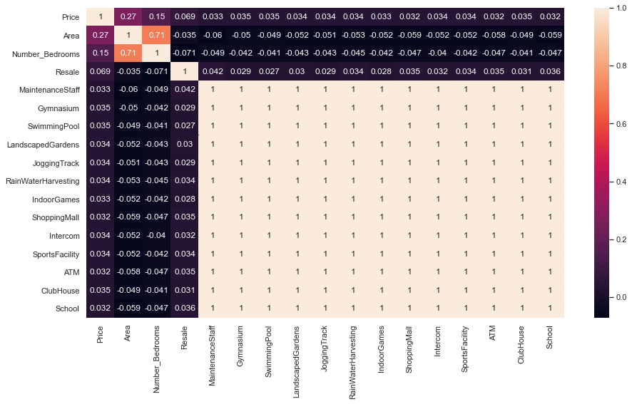

```python
hm = data[['Price', 'Area', 'Number_Bedrooms', 'Resale',
       'MaintenanceStaff', 'Gymnasium', 'SwimmingPool', 'LandscapedGardens',
       'JoggingTrack', 'RainWaterHarvesting', 'IndoorGames', 'ShoppingMall',
       'Intercom', 'SportsFacility', 'ATM', 'ClubHouse', 'School'
       ]]
plt.figure(figsize=(15,8))
sns.heatmap(hm.corr(),annot=True)
```

# This completes the guide on analysing the Properties datset!!!

```python
!jupyter nbconvert --to html Properties_Guide.ipynb
```

[output not shown]

[output not shown]

[output not shown]

[output cut: 141 more lines]

[output not shown]